# discrete distributions

–

Where n choose k (first part)

$$\frac{n!}{(n-k)!k!}$$

```r
choose(5,2) *
  .341^2 *
  (1 - .341)^3
```

```
## [1] 0.332786
```

```r
dbinom(2, 5, .341)
```

```
## [1] 0.332786
```

2. Historically, a Soldier hits a target at 50 meters 80% of the time. Assume shots are independent of one another.
1. What is the probability that the Soldier misses on the first two shots?
2. What is the probability that the Soldier misses a few in a row, and then hits the target on the 4th shot?
3. What is the probability that the Soldier requires at least 4 shots before hitting the target?

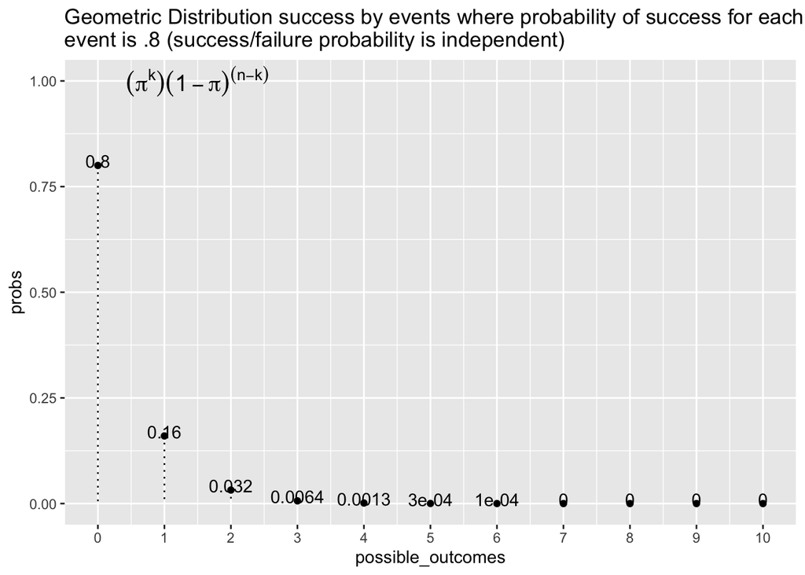

```r
library(tidyverse)

single_trial_prob <- .8

num_trials <- 10

0:num_trials ->
  possible_outcomes

dgeom(x = possible_outcomes,
       prob = single_trial_prob) ->
  probs

tibble(possible_outcomes, probs) %>%
  ggplot() +
  aes(x = possible_outcomes) +
  scale_x_continuous(breaks = possible_outcomes) +
  aes(y = probs) +
  geom_point() +
  aes(xend = possible_outcomes,
      yend = 0) +
  geom_segment(lty = "dotted") +
  labs(title = "Geometric Distribution success by events where probability of success for each event is .8  (success/failure probability is independent)" %>%
         str_wrap()) +
  geom_text(aes(label = probs %>% round(4)),
            nudge_y = .01) +
  annotate(geom = "text",
           x = 1.5,
           y = 1,
           label = "(pi^k)*(1-pi)^(n-k)",
           parse = TRUE,
           size = 5)
```

3. The weekly amount of diesel fuel your unit uses was observed, over a long period of time, to be approximately normally distributed with a mean of 400 gallons and a variance of 400 gallons^2.
1. If 420 gallons are budgeted for next week, what is the probability that the actual amount consumed will be within the budget?
2. If 450 gallons are budgeted for next week, what is the probability that the actual amount consumed will exceed the budgeted amount?
3. What is the probability your unit uses between 390 and 425 gallons of fuel

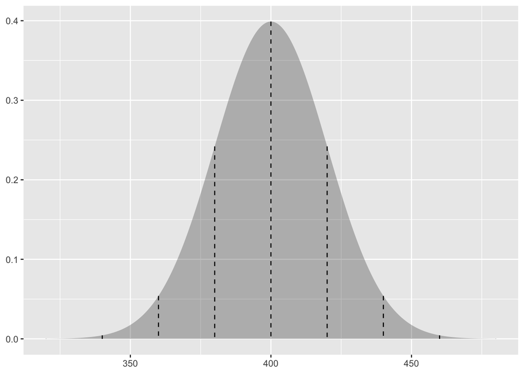

```r
library(ggxmean)
ggxmean:::stamp_space() +
  stamp_normal_dist(sd = 400^.5, mean = 400) +
  stamp_normal_dist_zlines(sd = 400^.5, # sd = 20
                           mean = 400,
                           height = 20) ->
basenormal
basenormal
```

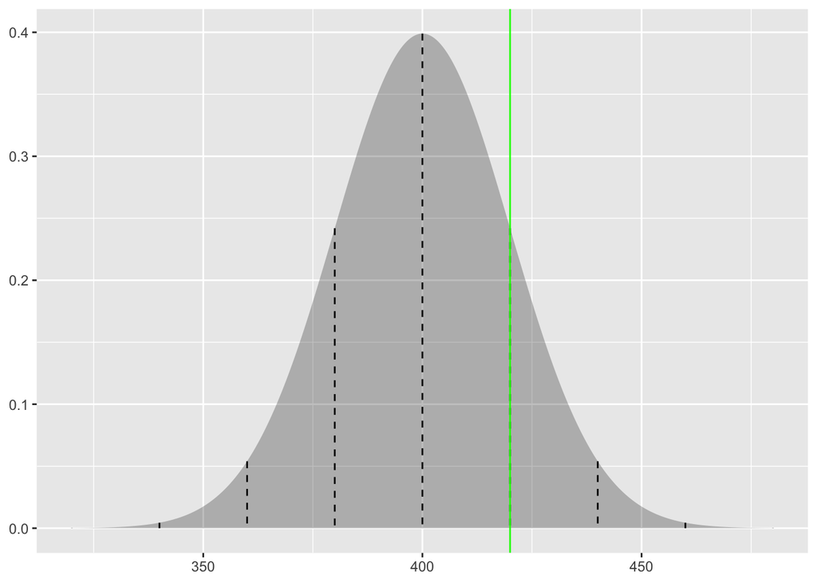

```r
basenormal +
  geom_vline(xintercept = 420, color = "green")
```

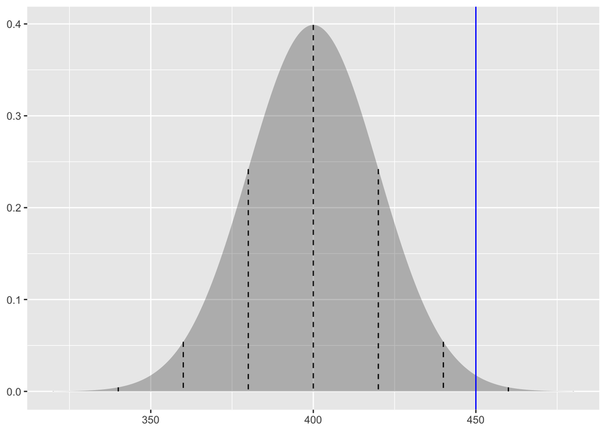

```r
basenormal +
  geom_vline(xintercept = 450, color = "blue")
```

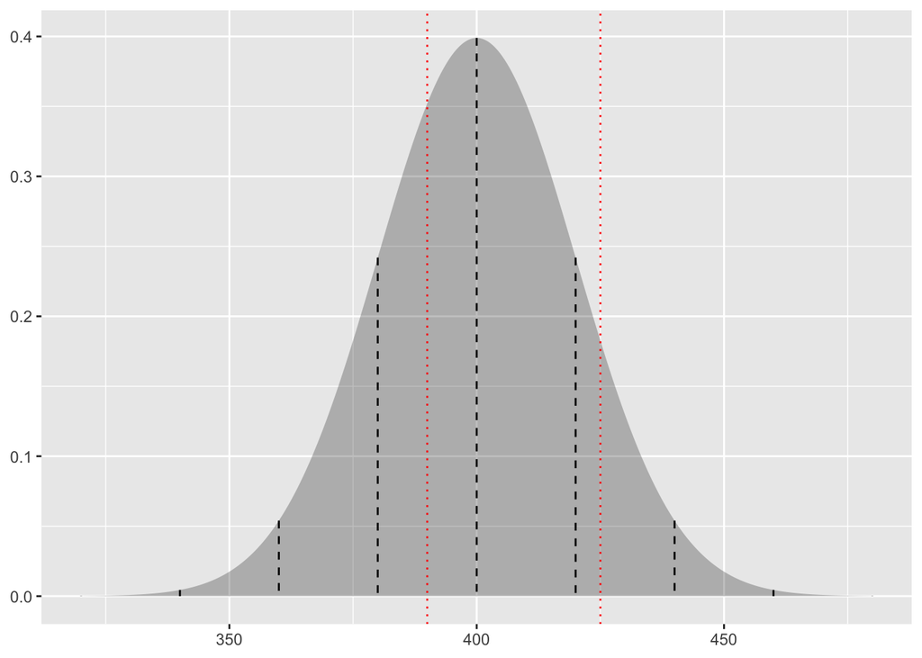

```r
basenormal +
  geom_vline(xintercept = c(390, 425),
             linetype = "dotted",
             color = "red")
```